# Sample Pay Gap Analysis in R

Created by cdo03c GitHub: https://github.com/cdo03c

Produced in January 2018

The following report is a template for conducting and presenting a snap shot Gender Pay-Gap Analysis in an organization. This report does not address changes overtime, which is an important consideration for understanding the scope of the problems and evaluating any interventions. This report will address the following questions: *Is there a significant difference in income between men and women in this organization?* Does the difference vary depending on other factors?

The sample data used to generate this report is a heavily modified combination of two sample data sets provided by Glassdoor.com and the Workplace Equality Government Agency (WEGA) of Australia for conducting gender pay gap analysis. This data structure is highly recommended as the minimum features that should be considered in a gender pay gap analysis, but may not reflect the specific structure of various organization. For more information about the data and its structure, please consult the ReadMe file for this project: https://github.com/cdo03c/pay_gap/blob/master/README.md.

### Gender Pay Gap

The following 2017 gender pay gap report explores the base pay for our 1299 staff may receive by gender and other factors, seeking to expose any imbalance. We will use report results to assess;

```
levels of gender equality in our workplace
balance of male and female employees at different levels
and how effectively talent is being maximised and rewarded.
```

Unlike equal pay, which refers to paying a man and a woman the same amount for the same, or similar work, a pay gap is the difference in average pay between men and women in an organisation. It is the result of gender or ethnic imbalance — having more women in junior roles or fewer women in senior roles, relative to men. This means having a pay gap is likely to persist until organisations have fair representation of men, women and ethnic minorities at every level — something we are passionate about addressing. Steps will be taken, where possible, to minimise or readdress any identified inequities going forward.

# Gender Balance

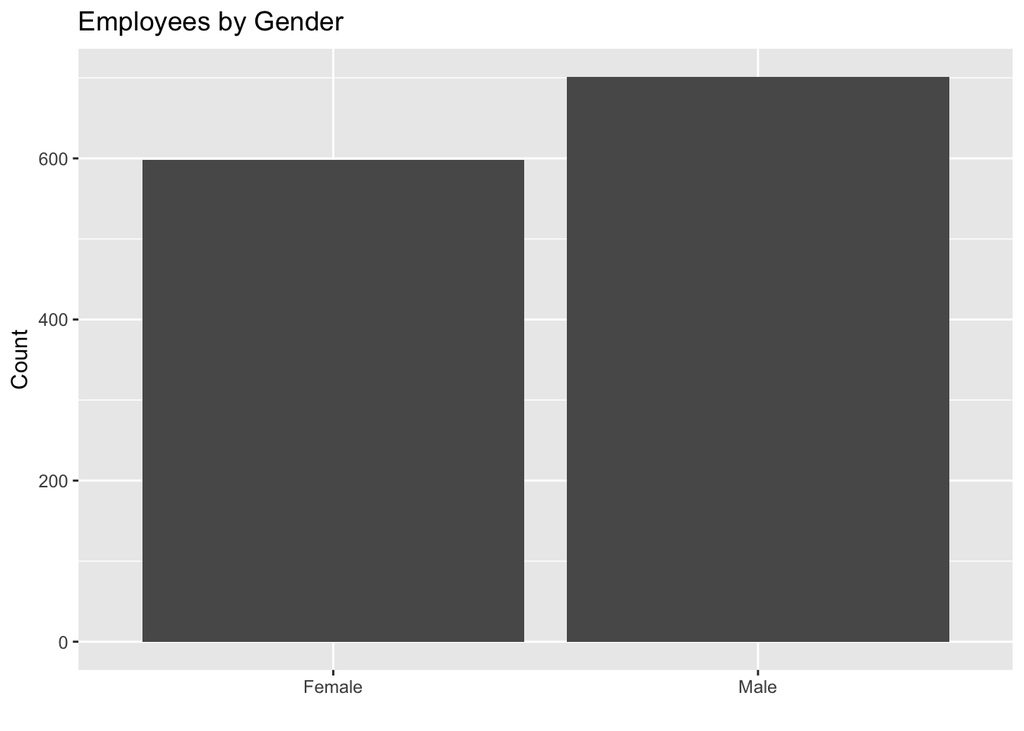

## Gender Pay Gap Summary

For the past year the median annual pay for male employees was $90000 ($93365.4265335235 mean) whereas for female employees it was $82341.5 ($83322.7240802676 mean), which results in a median gender pay gap of 9.3%.

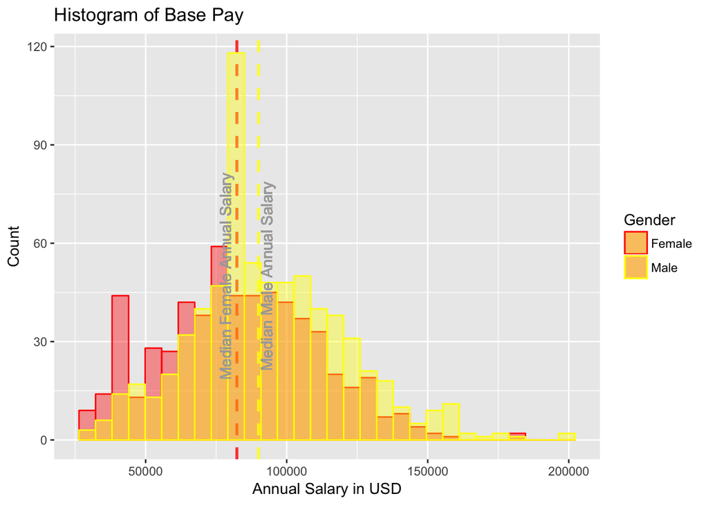

We can safely reject the null hypothesis that there is no statistically significant difference in base pay between male and female employees due to both the Welch T-Test (t = 6.5021324, df = 1260.6905402, p-value = 0) and the Wilcoxon-Mann-Whitney Test (W = 250367, p-value = 0) despite the fact that both male and female base pay are not normally distributed (Shapiro-Wilk Test as p-value < 0.05 Male: 0.0000005 and Female: 0.0000005)

Over the same time period the median total pay, which includes bonues, for male employees was $96525 whereas for female employees it was $88204.5, which results in a median gender pay gap of 9.43%.

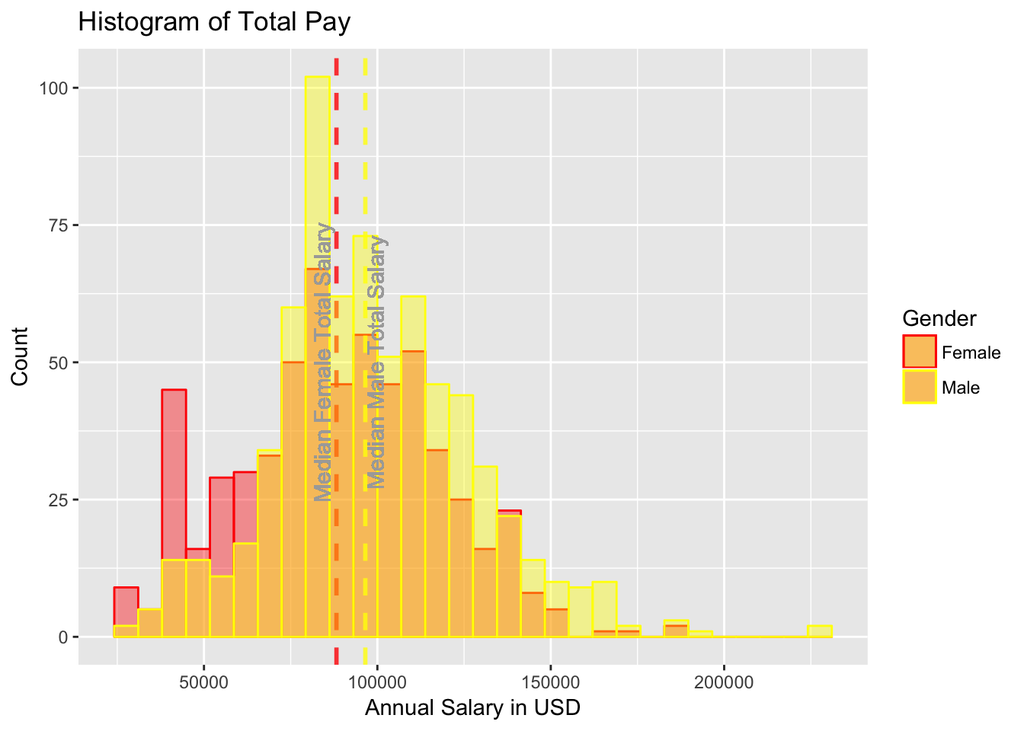

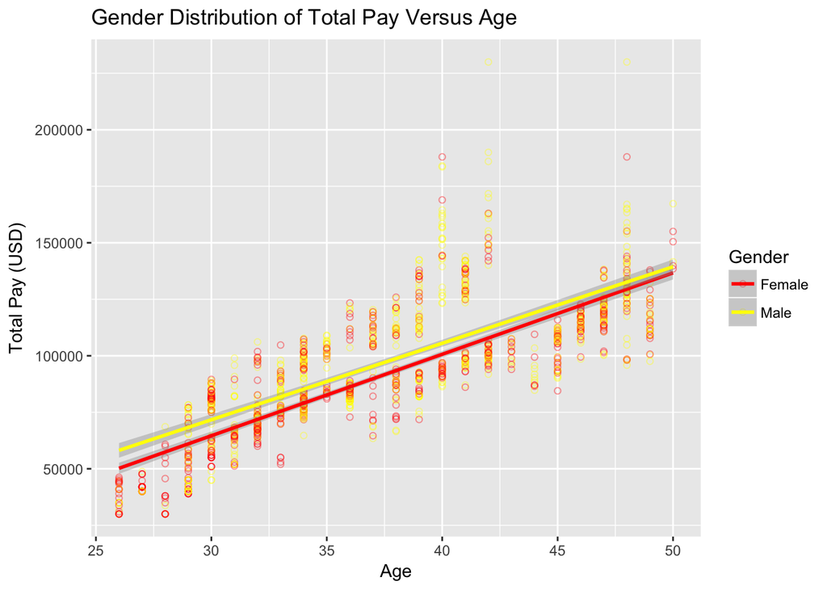

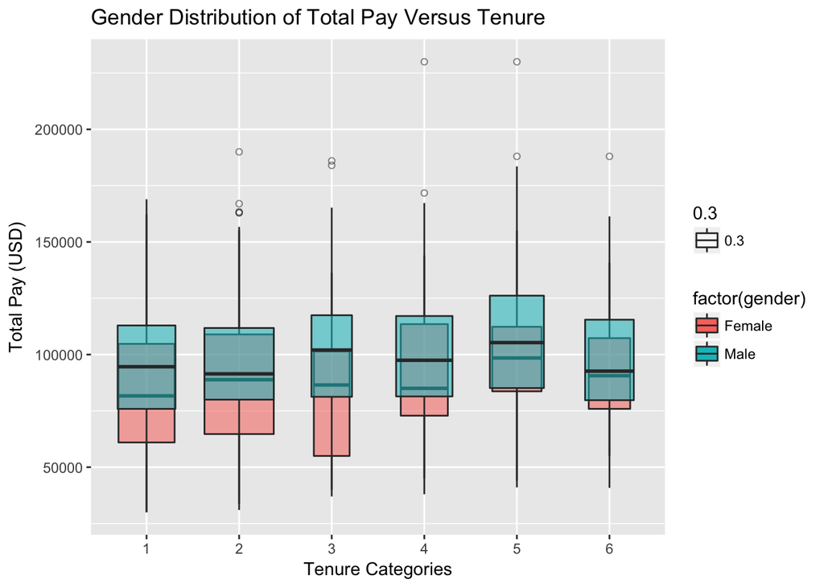

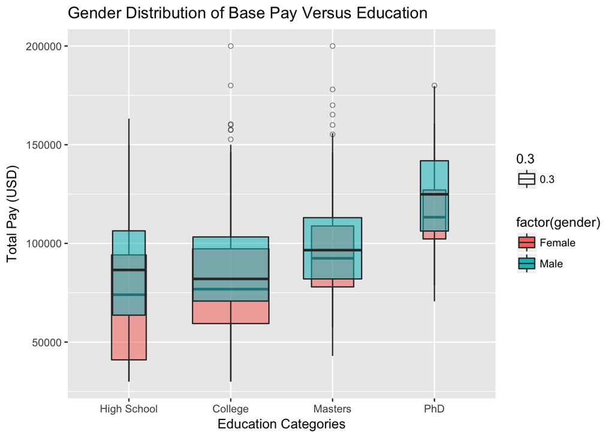